# Ggplot aesthetics RMarkdown

Miracle

2023-03-05

we will upload necessary

```r
library(ggplot2)
library(palmerpenguins)
```

we will start with simple graph ggplot(data = penguins)+ geom_point(mapping = aes(x=flipper_length_mm,y=body_mass_g))

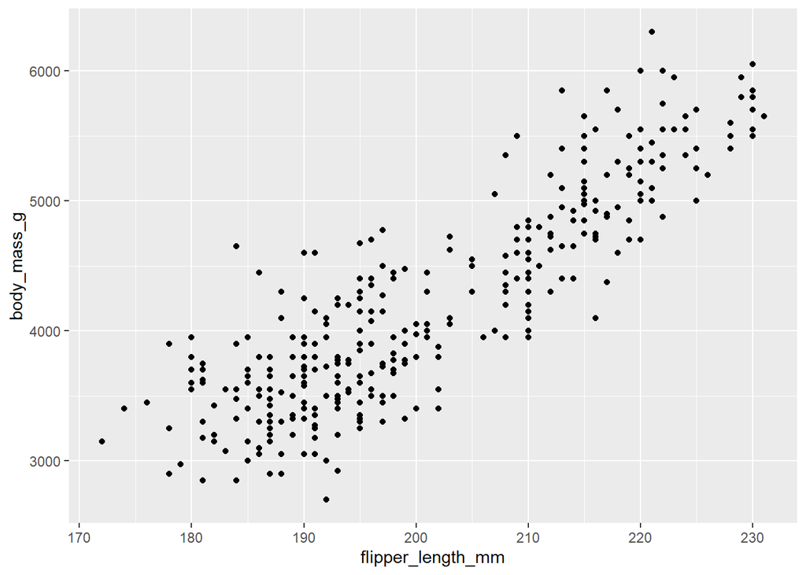

```r
ggplot(data = penguins)+ geom_point(mapping = aes(x=flipper_length_mm,y=body_mass_g))
```

## to create a visual with scatterplots

ggplot(data = penguins)+ geom_point(mapping = aes(x=flipper_length_mm,y=body_mass_g,alpha=species),color=“red”)

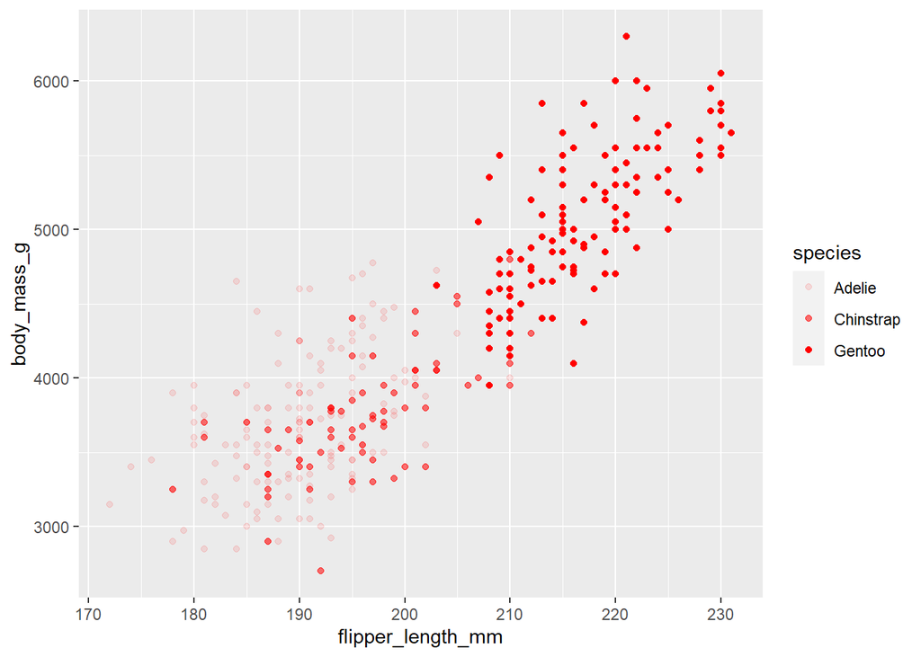

```r
ggplot(data = penguins)+
  geom_point(mapping = aes(x=flipper_length_mm,y=body_mass_g,alpha=species),color="red")
```

## creating a visual with smooth line

ggplot(data = penguins)+ geom_smooth(mapping = aes(x=flipper_length_mm,y=body_mass_g),color=“purple”)

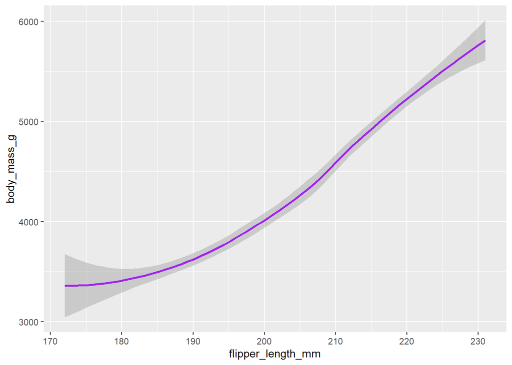

```r
ggplot(data = penguins)+ geom_smooth(mapping = aes(x=flipper_length_mm,y=body_mass_g),color="purple")
```

## creating two different visuals by combining them

ggplot(data = penguins)+ geom_point(mapping = aes(x=flipper_length_mm,y=body_mass_g,shape=species,color=species))+ geom_smooth(mapping = aes(x=flipper_length_mm,y=body_mass_g,linetype=species),color=“purple”)

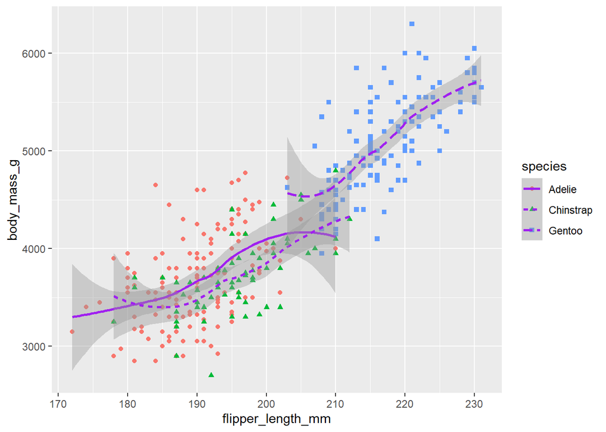

```r
ggplot(data = penguins)+
  geom_point(mapping = aes(x=flipper_length_mm,y=body_mass_g,shape=species,color=species))+
  geom_smooth(mapping = aes(x=flipper_length_mm,y=body_mass_g,linetype=species),color="purple")
```

## working with bar charts

###it gives colors to only outlines ggplot(data = diamonds)+ geom_bar(mapping = aes(x=cut,color=cut))

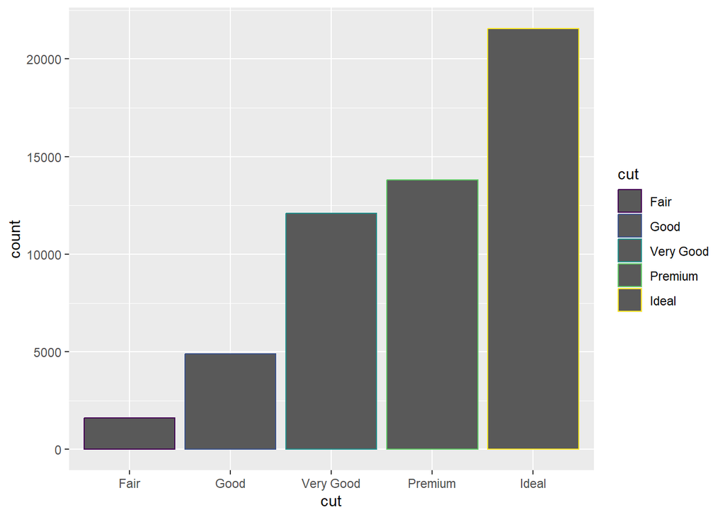

```r
ggplot(data = diamonds)+ geom_bar(mapping = aes(x=cut,color=cut))
```

### it fills the inside of bars with colors

ggplot(data=diamonds)+ geom_bar(mapping=aes(x=color,fill=cut))

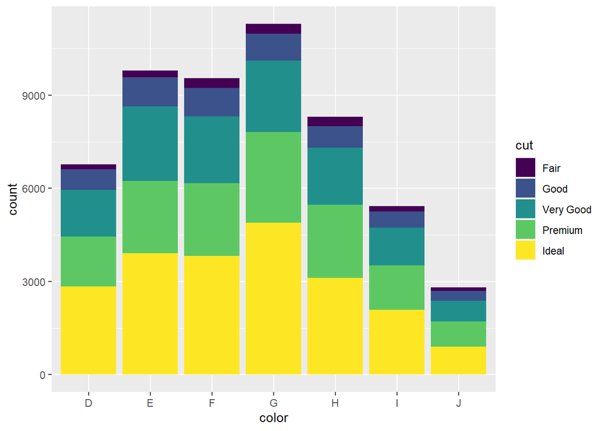

```r
ggplot(data=diamonds)+ geom_bar(mapping=aes(x=color,fill=cut))
```

we will add clarity to the bars ggplot(data=diamonds)+ geom_bar(mapping=aes(x=color,fill=clarity))

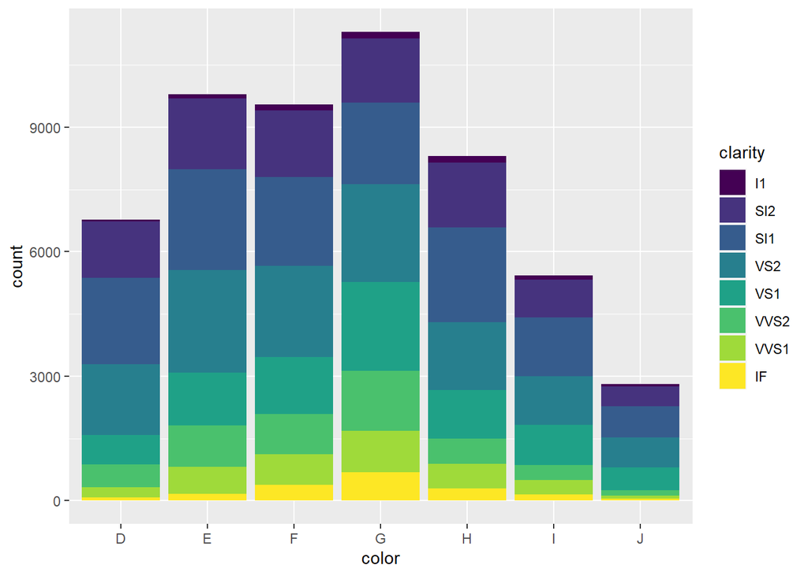

```r
ggplot(data=diamonds)+ geom_bar(mapping=aes(x=color,fill=clarity))
```

## creating separate plots for each species using FACET_WRAP funstion

ggplot(data = penguins)+ geom_point(mapping = aes(x=flipper_length_mm,y=body_mass_g,color=species))+ facet_wrap(~species)

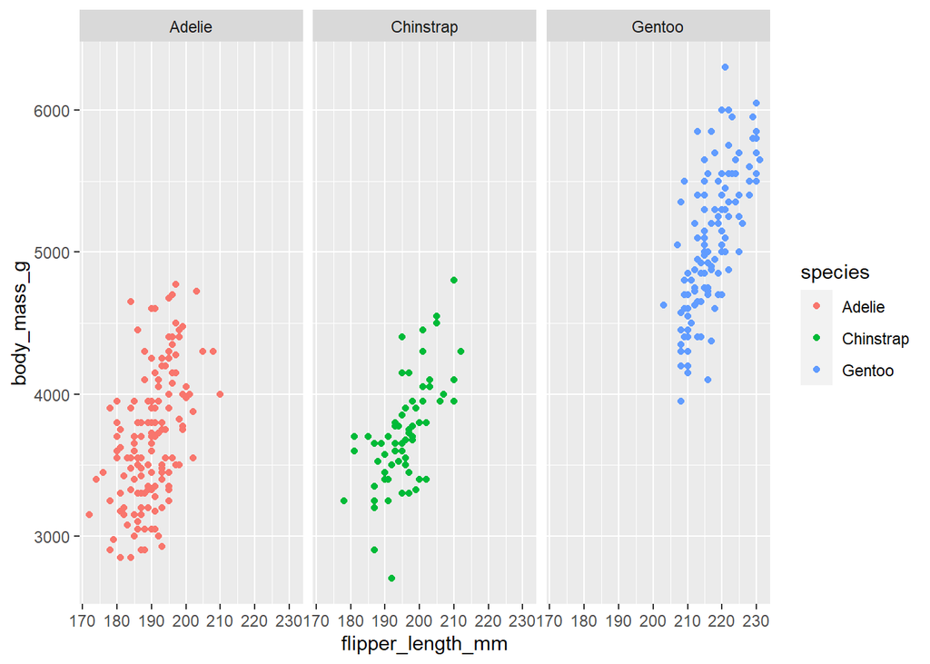

```r
ggplot(data = penguins)+
  geom_point(mapping = aes(x=flipper_length_mm,y=body_mass_g,color=species))+
  facet_wrap(~species)
```

ggplot(data=diamonds)+ geom_bar(mapping=aes(x=color,fill=cut))+ facet_wrap(~cut)

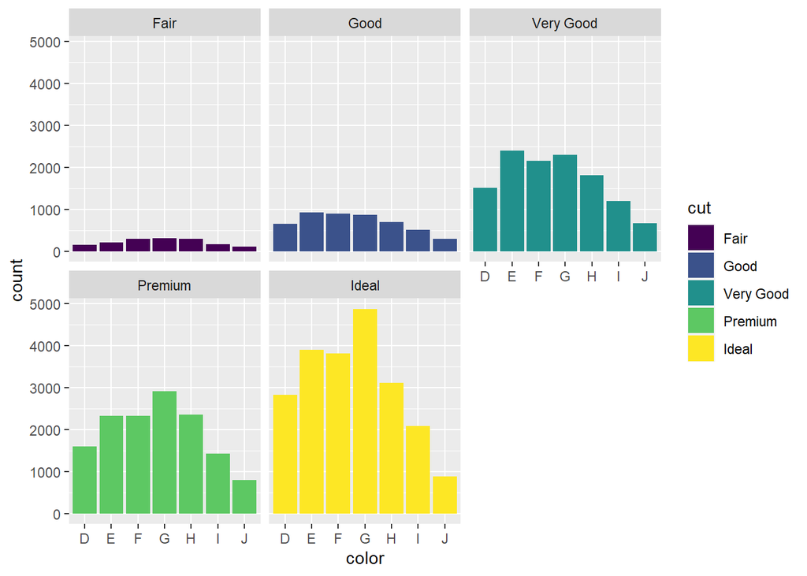

```r
ggplot(data=diamonds)+ geom_bar(mapping=aes(x=color,fill=cut))+ facet_wrap(~cut)
```

ggplot(data = penguins)+ geom_point(mapping = aes(x=flipper_length_mm,y=body_mass_g,color=species))+ facet_grid(sex~species)

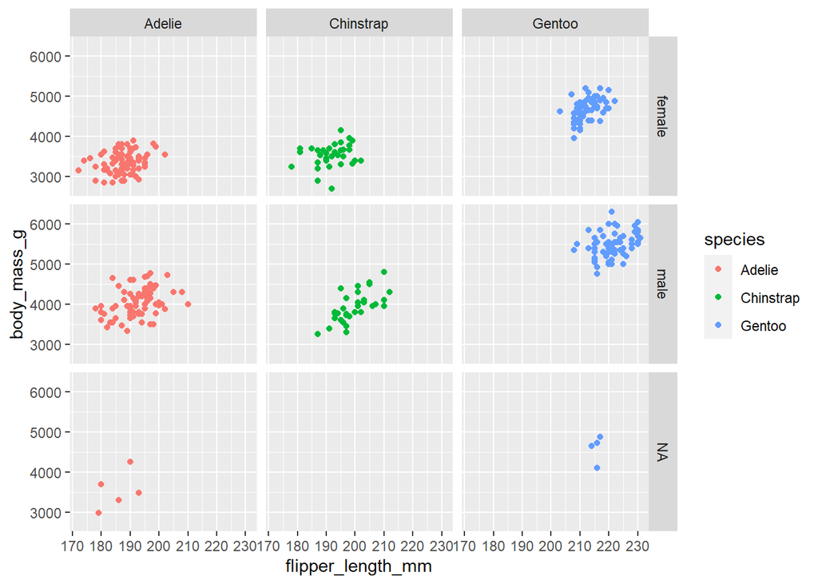

```r
ggplot(data = penguins)+
  geom_point(mapping = aes(x=flipper_length_mm,y=body_mass_g,color=species))+
  facet_grid(sex~species)
```